# Contextual data explore

Dan Killian

10/19/2021

# 1 Introduction

The South Sudan Monitoring and Evaluation Support Project (MESP) is conducting a household resilience survey in 13 counties. The purpose of this household survey is to obtain baseline data in the target areas for the indicators included in the Mission’s Performance Management Plan (PMP) and the Community Roadmap, in support of USAID/South Sudan’s Strategic Framework (2020-2024).

MESP has completed data collection in six counties, and as of October 2021 is carrying out data collection in the remaining seven counties. The study team is currently reviewing the data from six counties in advance of analysis of the full set of 13 counties. This document is one of a series of documents to review various measures and indices relating to resilience.

# 2 Contextual information

Environmental forces may play a role in affecting household resilience, and modeling that influence may help understand and measure household resilience. The study team gathered three sources of contextual data: conflict event data, a measure of human displacement by county, and the length of paved roads by county. This output will explore this contextual information to assess its suitability for incorporating into descriptive models of household resilience.

## 2.1 ACLED conflict events

### 2.1.1 Conflict-affected households

```r
acl <- read_csv(here("data/contextual/Violent_Events_by_EA.csv"))

acl <- acl %>%
  as.data.frame()

str(acl)
```

```
## 'data.frame':    218 obs. of  15 variables:
##  $ OBJECTID  : num  1 2 3 4 5 6 7 8 9 10 ...
##  $ Id        : num  0 1 2 3 4 5 6 7 8 9 ...
##  $ XCoord    : num  31.5 31.4 31.4 31.4 31.4 ...
##  $ YCoord    : num  7.52 7.45 7.46 7.46 7.72 ...
##  $ treat_phas: num  720401001202 720401003202 720401003203 720401003204 720402001201 ...
##  $ Date_Ear  : chr  "6/1/2021 0:00" "5/28/2021 0:00" "6/10/2021 0:00" "5/28/2021 0:00" ...
##  $ E_15km_30D: num  NA NA NA NA NA NA NA NA NA NA ...
##  $ E_15km_60D: num  NA NA NA NA NA NA NA NA NA NA ...
##  $ E_15km_90D: num  NA NA NA NA NA NA NA NA NA NA ...
##  $ E_30km_30D: num  NA NA NA NA NA NA NA NA NA NA ...
##  $ E_30km_60D: num  NA NA NA NA NA NA NA NA NA NA ...
##  $ E_30km_90D: num  NA NA NA NA NA NA NA NA NA NA ...
##  $ E_45km_30D: num  NA NA NA NA NA NA NA NA NA NA ...
##  $ E_45km_60D: num  NA NA NA NA NA NA NA NA NA NA ...
##  $ E_45km_90D: num  NA NA NA NA NA NA NA NA NA NA ...
```

```r
acl[,7:15][is.na(acl[,7:15])] <- 0

out <- dat %>%
  left_join(acl, by=c("ea"="treat_phas")) %>%
  filter(!is.na(q_601)) %>%
  rename(conflict=q_601)
```

```r
set.seed(4523)

#library(caret)

index <- createDataPartition(out$treat_phase, p=.7, list=F)

train <- out[index,]
test <- out[-index,]

r1 <- randomForest(as.factor(conflict) ~ E_15km_30D + E_15km_60D + E_15km_90D +
                     E_30km_30D + E_30km_60D + E_30km_90D +
                     E_45km_30D + E_45km_60D + E_45km_90D,
                   data=out)

r1
```

```
##
## Call:
##  randomForest(formula = as.factor(conflict) ~ E_15km_30D + E_15km_60D +      E_15km_90D + E_30km_30D + E_30km_60D + E_30km_90D + E_45km_30D +      E_45km_60D + E_45km_90D, data = out)
##                Type of random forest: classification
##                      Number of trees: 500
## No. of variables tried at each split: 3
##
##         OOB estimate of  error rate: 23.5%
## Confusion matrix:
##      0   1 class.error
## 0 2015 279       0.122
## 1  552 694       0.443
```

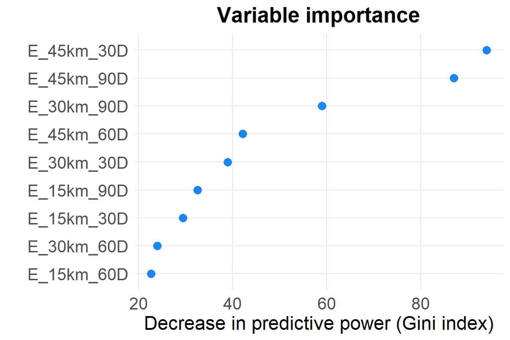

Figure 2.1: Variable importance, ACLED conflict events and reporting that the community is conflict-affected

The two most important variables are events within 45 kilometers, and either 30 or 90 days.

### 2.1.2 Food security

```
##
## Call:
##  randomForest(formula = fies_raw ~ E_15km_30D + E_15km_60D + E_15km_90D +      E_30km_30D + E_30km_60D + E_30km_90D + E_45km_30D + E_45km_60D +      E_45km_90D, data = out)
##                Type of random forest: regression
##                      Number of trees: 500
## No. of variables tried at each split: 3
##
##           Mean of squared residuals: 1.49
##                     % Var explained: 12.1
```

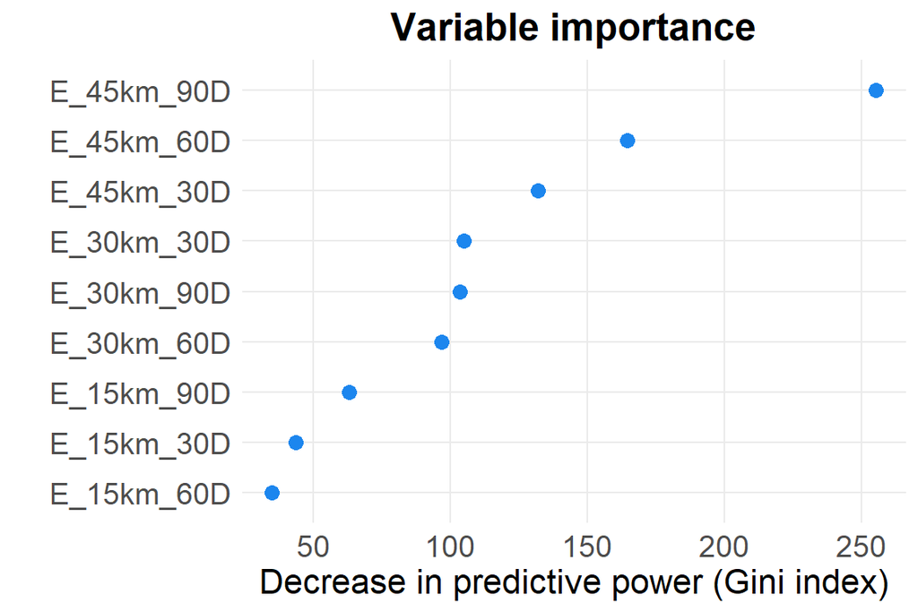

Figure 2.2: Variable importance, ACLED conflict events and food insecurity

```r
#describe(out$fies_raw)

out <- out %>%
  mutate(foodsec_sc = scale(fies_raw)) %>%
  filter(!is.na(fies_raw))

# describe(out$foodsec_sc)
#
# ggplot(out, aes(foodsec_sc)) +
#   geom_density()

rfood <- randomForest(fies_raw ~ E_15km_30D + E_15km_60D + E_15km_90D +
                     E_30km_30D + E_30km_60D + E_30km_90D +
                     E_45km_30D + E_45km_60D + E_45km_90D,
                   data=out)

rfood
```

The most important variables are 45 kilometers and 30, 60, or 90 days previous to the interview.

### 2.1.3 Concluding thoughts, conflict event data

We needed to calibrate the geographic and temporal buffer zone around a conflict event in terms of the extent to which the events affected a measure of resilience. We tested a combination of geographic (15, 30, and 45 kilometers) and temporal (30, 60, and 90 days prior to the first survey interview of a given sampling point) windows on two outcomes: whether or not the respondent reported that their household or community was conflict affected, and the degree of food insecurity in the household. We used a variable selection routine known as the random forest to help identify the appropriate buffer, where ‘appropriate’ was scored according to a measure of predictive accuracy a given buffer had on a given outcome.

For both outcomes, the variable selection routine suggested that we should use the 45 kilometer buffer. There is more flexibility around the temporal window, but indications are that the 90 day temporal window is likely the most predictive.

Therefore, ACLED conflict events will use the 45 kilometer, 90 day window as the appropriate buffers by which to generate a count of events that affect a given sampling point.